# Results Section Two

## Modeling Census Tract Level Evictions : Richmond: Visualizing An Index Of Eviction Intensity

The Eviction Intensity Index we created from our regression model was used to rank all census tracts in U.S. cities that are comparable in size to Richmond. The word cloud below visualizes the frequency that census tracts with the words “Richmond City” show up in a list of the top 320 most eviction intense tracts in the U.S. Richmond is clearly among the most prominent cities that appear below, second only to Greensboro, NC. There are three other Virginia cities used in our analysis: Newport News, VA, Chesapeake, VA, and Hampton, VA. An analysis with only tracts in the state of Virginia shows a similar pattern with the tracts in Richmond dominating the top spots.

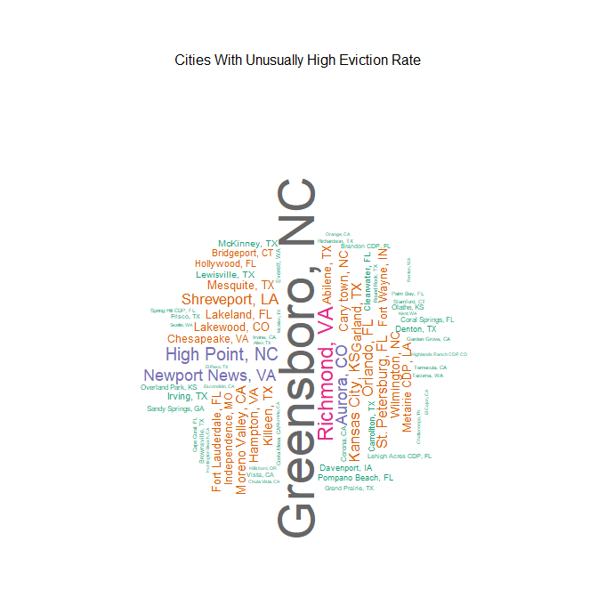

In the visualization below, we have an eviction indicator for census tracts in the city of Richmond.

Eviction Intensity across Richmond City Census Tracts

[interactive chart not shown]

Eviction Intensity across Richmond City Census Tracts

[Continue to Results Section Three](https://boya66.github.io/Richmond_website/findings/results-section-three/)